# Introduction to Biostatistics

# 1 Learning objectives

## 1.1 Learning objectives

- **Conduct** analysis on time-to-event outcomes
  - Kaplan-Meier curve, proportional hazards regression
- **Describe** issues related to time-to-event analysis
  - Censoring, proportional hazards, time-varying predictors

# 2 Time-to-event outcomes

## 2.1 Time-to-event variable

- Also called survival, time to survival, time to failure, event history analysis, reliability analysis
- **Non-negative** (only 0 and positive numbers)
- **Right skewed** with long right tail
- Potentially **censored**
  - Event is not observed *during the study*
  - Don’t know if/when event happens

## 2.2 Censoring

- **Right censoring**: Event has not occurred by the end of the observation period
  - Follow patients for 1 year, some patients are still alive at end
- **Left censoring**: Time started before the study started
  - Recruit cancer patients, but diagnosis occurred some period of time before the study started
- **Interval censoring**: Event occurred between two discrete observation periods, but you don’t know exactly when
  - Treat time as discrete or continuous?

## 2.3 Censoring

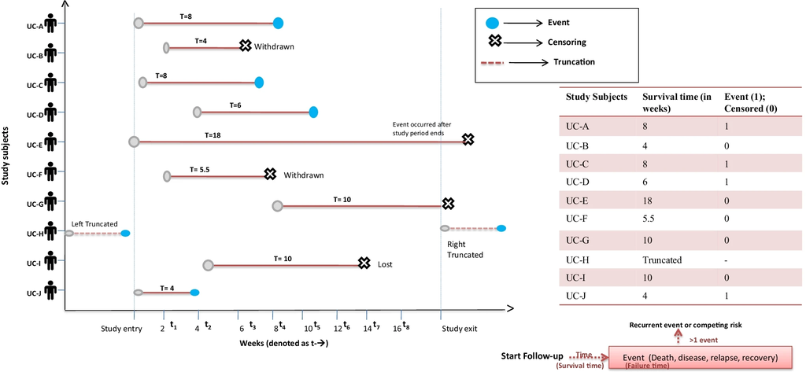

- From Rai et al. (2021)

## 2.4 Data for censoring

- Two variables **together** define the outcome
  - **Time-to-event variable**
    - If event happened, time until event
    - If event didn’t happen, time until withdrawal or end of study
  - **Censoring variable**
    - If event happened: 1
    - If event didn’t happen: 0 (censored)
    - Example: coded 1/2 for [“historical” reasons](https://cran.r-project.org/web/packages/survival/refman/survival.html#lung)

## 2.5 Data

- `cancer` dataset in **survival** package
- n = 228 observations on 10 variables
  - `inst`: Institution code
  - `time`: Survival time in **days**
  - `status`: censoring status 1=censored, 2=dead
  - `age`: Age in years
  - `sex`: Male=1 Female=2
  - `ph.ecog`: ECOG performance score as rated by the physician. 0=asymptomatic, 1= symptomatic but completely ambulatory, 2= in bed <50% of the day, 3= in bed > 50% of the day but not bedbound, 4 = bedbound
  - `ph.karno`: Karnofsky performance score (bad=0-good=100) rated by physician
  - `pat.karno`: Karnofsky performance score as rated by patient
  - `meal.cal`: Calories consumed at meals
  - `wt.loss`: Weight loss in last six months (pounds)

```r
library(survival)
data(cancer)
table(cancer$status)
```

```
  1   2
 63 165
```

# 3 Survival curves

## 3.1 Survival object

- `Surv()` function from **survival** package
- Combines time-to-event variable and censoring variable
  - Number is survival time
  - 63 are censored: Alive (`status` = 1) at end of study (`+`)
  - 165 are not: Dead (`status` = 2) at end of study (No `+`)

## 3.2 Survival object

```r
s <- Surv(cancer$time, cancer$status)
s
```

```
  [1]  306   455  1010+  210   883  1022+  310   361   218   166   170   654
 [13]  728    71   567   144   613   707    61    88   301    81   624   371
 [25]  394   520   574   118   390    12   473    26   533   107    53   122
 [37]  814   965+   93   731   460   153   433   145   583    95   303   519
 [49]  643   765   735   189    53   246   689    65     5   132   687   345
 [61]  444   223   175    60   163    65   208   821+  428   230   840+  305
 [73]   11   132   226   426   705   363    11   176   791    95   196+  167
 [85]  806+  284   641   147   740+  163   655   239    88   245   588+   30
 [97]  179   310   477   166   559+  450   364   107   177   156   529+   11
[109]  429   351    15   181   283   201   524    13   212   524   288   363
[121]  442   199   550    54   558   207    92    60   551+  543+  293   202
[133]  353   511+  267   511+  371   387   457   337   201   404+  222    62
[145]  458+  356+  353   163    31   340   229   444+  315+  182   156   329
[157]  364+  291   179   376+  384+  268   292+  142   413+  266+  194   320
[169]  181   285   301+  348   197   382+  303+  296+  180   186   145   269+
[181]  300+  284+  350   272+  292+  332+  285   259+  110   286   270    81
[193]  131   225+  269   225+  243+  279+  276+  135    79    59   240+  202+
[205]  235+  105   224+  239   237+  173+  252+  221+  185+   92+   13   222+
[217]  192+  183   211+  175+  197+  203+  116   188+  191+  105+  174+  177+
```

## 3.3 Survival curve

- Unconditional survival curve **using the survival object**
  - `survfit()` function from **survival** package
  - `~ 1` means “intercept only” or “mean only”: **No predictors**
  - `n` = total number of observations
  - `events` = total number **dead** at end of study
  - `median`, LCL, UCL for survival time (in **days**)

```r
survfit(s ~ 1)
```

```
Call: survfit(formula = s ~ 1)

       n events median 0.95LCL 0.95UCL
[1,] 228    165    310     285     363
```

## 3.4 Survival curve

- Can also specify the survival object *within* the `survfit()` function
  - Same results
  - This is useful to build on, adding predictors

```r
survfit(Surv(time, status) ~ 1, data = cancer)
```

```
Call: survfit(formula = Surv(time, status) ~ 1, data = cancer)

       n events median 0.95LCL 0.95UCL
[1,] 228    165    310     285     363
```

## 3.5 Life table (/ risk table)

- `summary()` on survival curve object gives a **life table**
  - `time` = time-to-event variable values
  - `n.risk` = number still alive at this point
  - `n.event` = number of events (i.e., deaths)
  - `survival` = proportion of sample still alive at this time

```r
sfit <- survfit(Surv(time, status) ~ 1, data = cancer)
summary(sfit)
```

```
Call: survfit(formula = Surv(time, status) ~ 1, data = cancer)

 time n.risk n.event survival std.err lower 95% CI upper 95% CI
    5    228       1   0.9956 0.00438       0.9871        1.000
   11    227       3   0.9825 0.00869       0.9656        1.000
   12    224       1   0.9781 0.00970       0.9592        0.997
   13    223       2   0.9693 0.01142       0.9472        0.992
   15    221       1   0.9649 0.01219       0.9413        0.989
   26    220       1   0.9605 0.01290       0.9356        0.986
   30    219       1   0.9561 0.01356       0.9299        0.983
   31    218       1   0.9518 0.01419       0.9243        0.980
   53    217       2   0.9430 0.01536       0.9134        0.974
   54    215       1   0.9386 0.01590       0.9079        0.970
   59    214       1   0.9342 0.01642       0.9026        0.967
   60    213       2   0.9254 0.01740       0.8920        0.960
```

[output cut: 127 more lines]

## 3.6 Kaplan-Meier curve

- Life table is unmanageable with many time values
  - Hard to interpret
- Kaplan-Meier is a **graphical representation** of the life table
  - Simplest: Use `plot()` on survival curve (base R)
  - Better option: `ggsurvfit()` function in **ggsurvfit** package

## 3.7 Kaplan-Meier curve

```r
library(ggsurvfit)
ggsurvfit(sfit)
```

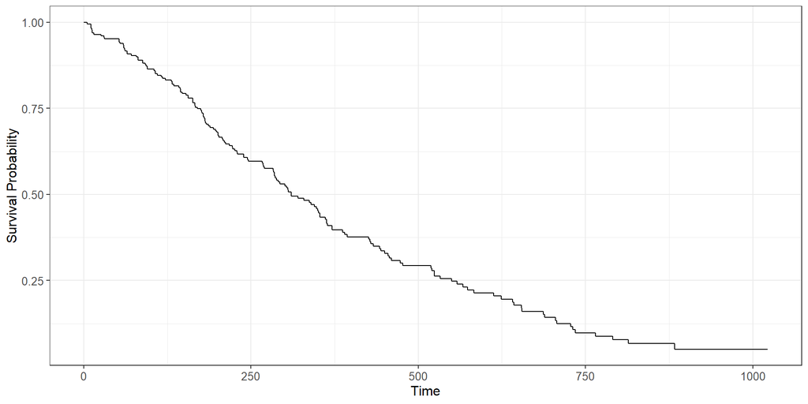

## 3.8 Kaplan-Meier curve

```r
ggsurvfit(sfit) +
  add_confidence_interval() + add_risktable()
```

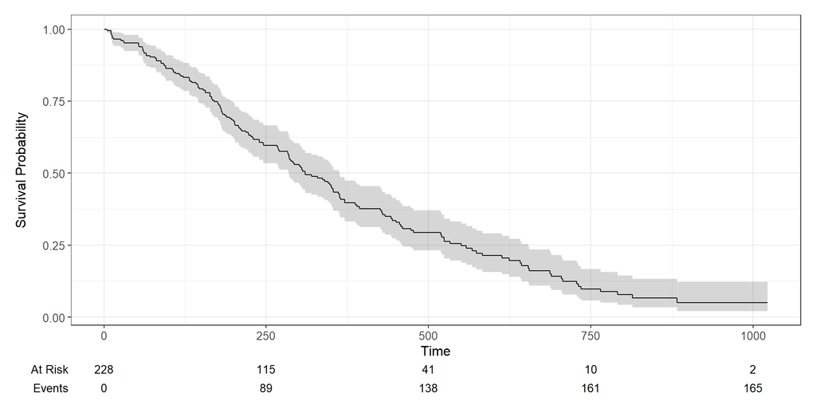

## 3.9 Kaplan-Meier curve is **ggplot** object

```r
ggsurvfit(sfit) +
  add_confidence_interval() +
  geom_vline(xintercept = 365, linetype = "dashed", color = "blue") +
  geom_vline(xintercept = 730, linetype = "dashed", color = "blue") +
  labs(x = "Time (days)") +
  theme_classic(base_size = 16)
```

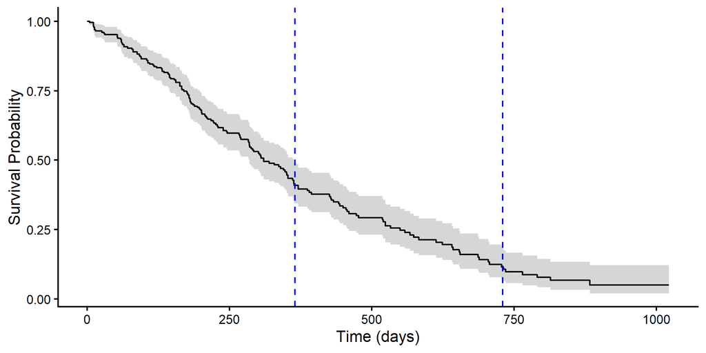

## 3.10 Probability of surviving to some time

```r
summary(survfit(Surv(time, status) ~ 1, data = cancer), times = 365)
```

```
Call: survfit(formula = Surv(time, status) ~ 1, data = cancer)

 time n.risk n.event survival std.err lower 95% CI upper 95% CI
  365     65     121    0.409  0.0358        0.345        0.486
```

- 65 still alive, 121 have died
- Accounts for **censoring**

## 3.11 Probability of surviving to some times

```r
summary(survfit(Surv(time, status) ~ 1, data = cancer), times = c(365, 730))
```

```
Call: survfit(formula = Surv(time, status) ~ 1, data = cancer)

 time n.risk n.event survival std.err lower 95% CI upper 95% CI
  365     65     121    0.409  0.0358       0.3447        0.486
  730     13      38    0.116  0.0283       0.0716        0.187
```

- 1 year: 65 still alive, 121 have died so far
- 2 years: 13 still alive, 38 have died since 365 days

## 3.12 Compare two groups: Log-rank test

- `survdiff()` function in **survival** package
- Compare how many **events** in each group

```r
survdiff(Surv(time, status) ~ sex, data = cancer)
```

```
Call:
survdiff(formula = Surv(time, status) ~ sex, data = cancer)

        N Observed Expected (O-E)^2/E (O-E)^2/V
sex=1 138      112     91.6      4.55      10.3
sex=2  90       53     73.4      5.68      10.3

 Chisq= 10.3  on 1 degrees of freedom, p= 0.001
```

- `N` = total number in each group (here, `sex`)
- `Observed` = number of dead (`status` = 2)

## 3.13 Double check the numbers

```r
sex_by_status <- table(cancer$sex, cancer$status)
rownames(sex_by_status) <- c("Male", "Female")
colnames(sex_by_status) <- c("Censored", "Dead")
sex_by_status
```

```
         Censored Dead
  Male         26  112
  Female       37   53
```

## 3.14 Kaplan-Meier curve: Groups

```r
sfit2 <- survfit(Surv(time, status) ~ sex, data = cancer)
ggsurvfit(sfit2)
```

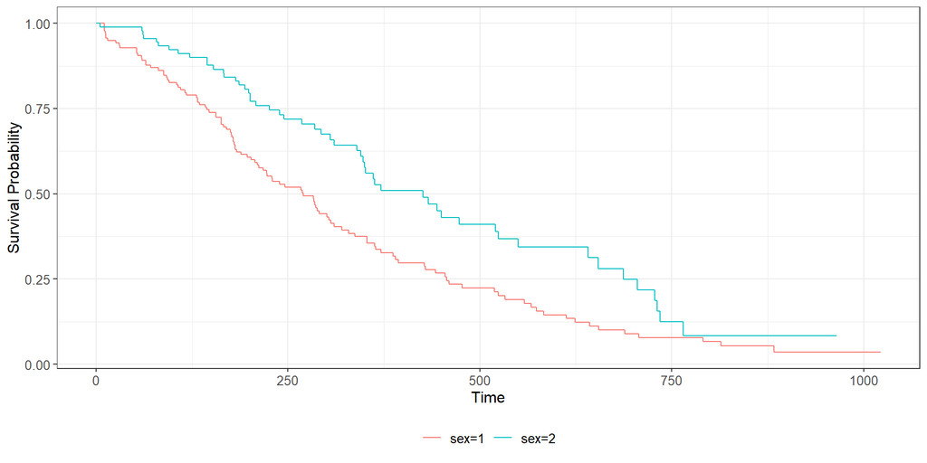

## 3.15 Kaplan-Meier curve: Groups

```r
ggsurvfit(sfit2) +
  add_confidence_interval() + add_risktable()
```

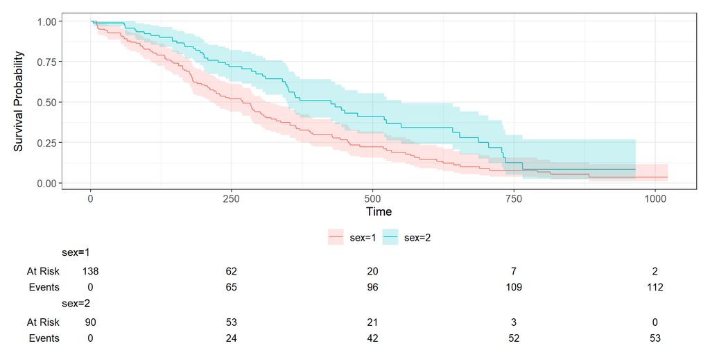

# 4 Cox regression

## 4.1 Cox regression

- Also known as **proportional hazards** model
- Extends *survival curves* to include **multiple predictors and/or continuous predictors**
  - K-M or log-rank is a $t$-test, Cox regression is linear regression
  - Model-based with statistical tests, not just *descriptive*
- Can be considered a **generalized linear model** but often excluded

## 4.2 Cox regression

$$log(h(t)) = log(h_0(t)) + b_1 X_1 + b_2 X_2 + \cdots + b_p X_p$$

- Hazard = instantaneous event (death) rate at time $t$
  - $h(t)$ = hazard as a function of time $t$
  - **Function** of $t$
- $h_0(t)$ = baseline hazard **function** = hazard as a function of $t$ when all predictors equal 0
  - Like intercept, but it’s a **function** of $t$

## 4.3 Cox regression

- `coxph()` function from **survival** package
  - `Surv(time, status)` (survival object) is outcome
  - Variables to the right of `~` are predictors
  - `data` for the analysis
  - **Really similar** to `lm()` and `glm()`

```r
coxph(Surv(time, status) ~ sex, data = cancer)
```

## 4.4 Cox regression

```r
cox1 <- coxph(Surv(time, status) ~ sex, data = cancer)
summary(cox1)
```

```
Call:
coxph(formula = Surv(time, status) ~ sex, data = cancer)

  n= 228, number of events= 165

       coef exp(coef) se(coef)      z Pr(>|z|)
sex -0.5310    0.5880   0.1672 -3.176  0.00149 **
---
Signif. codes:  0 '***' 0.001 '**' 0.01 '*' 0.05 '.' 0.1 ' ' 1

    exp(coef) exp(-coef) lower .95 upper .95
sex     0.588      1.701    0.4237     0.816

Concordance= 0.579  (se = 0.021 )
Likelihood ratio test= 10.63  on 1 df,   p=0.001
Wald test            = 10.09  on 1 df,   p=0.001
Score (logrank) test = 10.33  on 1 df,   p=0.001
```

## 4.5 Interpretation

$$log(h(t)) = log(h_0(t)) \color{OrangeRed}{- 0.531 sex}$$

- **Coefficient** for a predictor
  - $b_1 = -0.531, s.e. = 0.1672, z = -3.176, p<.01$
- **Hazard ratio** for a predictor
  - $e^{b_1} = e^{-0.531} = 0.588$ w CI: $[0.4237,0.816]$
  - 1 unit change in `sex`: **Hazard** is **multiplied by** 0.588
  - Women (`sex` = 2) vs men (`sex` = 1): 58.8% of the risk of **death**
  - Flip the groups: `exp(-coef)` = 1.701 in output

## 4.6 Baseline hazard function

$$log(h(t)) = \color{OrangeRed}{log(h_0(t))} + -0.531 sex$$

- No *constant* intercept
  - Baseline hazard **function**: Doesn’t go in equation
- $h_0(t)$ = baseline hazard **function** = hazard as a function of $t$ when all predictors equal 0
  - How the risk of event per time changes over time at **baseline** levels of covariates (i.e., when all predictors = 0)

## 4.7 Proportional hazard assumption

- **Assumption**: Hazard ratio is **constant** at all values of $t$
  - Is **hazard ratio** between men and women ($e^{b_1}$) same at all $t$?
- Test proportional hazards assumption: `cox.zph()` in **survival** package

```r
cox.zph(cox1)
```

```
       chisq df     p
sex     2.86  1 0.091
GLOBAL  2.86  1 0.091
```

- Significant test: Hazard ratio **changes** with $t$
- NS test: Hazard ratio is **constant** across $t$ (assumption met)

## 4.8 Proportional hazard assumption

- If this assumption is **not met**
  - Hazard ratio **changes** with time ($t$)
  - Time-varying predictors (i.e., predictors that change with $t$)
    - Illness severity, changing comorbidities, etc.
- This is a more complicated model
  - https://cran.r-project.org/web/packages/survival/vignettes/timedep.pdf

## 4.9 One more example

```r
cox2 <- coxph(Surv(time, status) ~ sex + age, data = cancer)
summary(cox2)
```

```
Call:
coxph(formula = Surv(time, status) ~ sex + age, data = cancer)

  n= 228, number of events= 165

         coef exp(coef)  se(coef)      z Pr(>|z|)
sex -0.513219  0.598566  0.167458 -3.065  0.00218 **
age  0.017045  1.017191  0.009223  1.848  0.06459 .
---
Signif. codes:  0 '***' 0.001 '**' 0.01 '*' 0.05 '.' 0.1 ' ' 1

    exp(coef) exp(-coef) lower .95 upper .95
sex    0.5986     1.6707    0.4311    0.8311
age    1.0172     0.9831    0.9990    1.0357

Concordance= 0.603  (se = 0.025 )
Likelihood ratio test= 14.12  on 2 df,   p=9e-04
Wald test            = 13.47  on 2 df,   p=0.001
Score (logrank) test = 13.72  on 2 df,   p=0.001
```

## 4.10 Software

https://rviews.rstudio.com/2017/09/25/survival-analysis-with-r/

## 4.11 In class

- Some more time-to-event models
  - Plots
  - Interpret hazard ratios